# M2859 Visualización de datos PEC2

None

[figure not shown]

M2859 Visualización de datos PEC2

2023-1 · Máster universitario en Ciencia de datos (Data science)

Estudios de Informática, Multimedia y Telecomunicación

# PEC2 Estudio de técnicas de visualización de datos

En esta actividad el estudiante tendrá que crear tres pequeñas visualizaciones usando técnicas diferentes. Cada estudiante tendrá que escoger unos datos idóneos para cada una de las técnicas propuestas y decidir con qué software las crea. En este caso, se escoge python como software y las técnicas son:

1. Pyramid Charts
2. Venn Diagrams
3. OHLC Charts

**Nombre y apellidos: FRANCISCO JAVIER GHERSI LAZARO**

# Pyramid Charts

Fuente del conjunto de datos: [Population pyramid by country from 1950-2022](https://www.kaggle.com/datasets/prasertk/population-pyramid-by-country-from-19502022) El dataset presenta el cambio en la forma de la pirámide de población de varios paises en siete décadas. En particular, visualizamos la piramide de población de España en el año 2022:

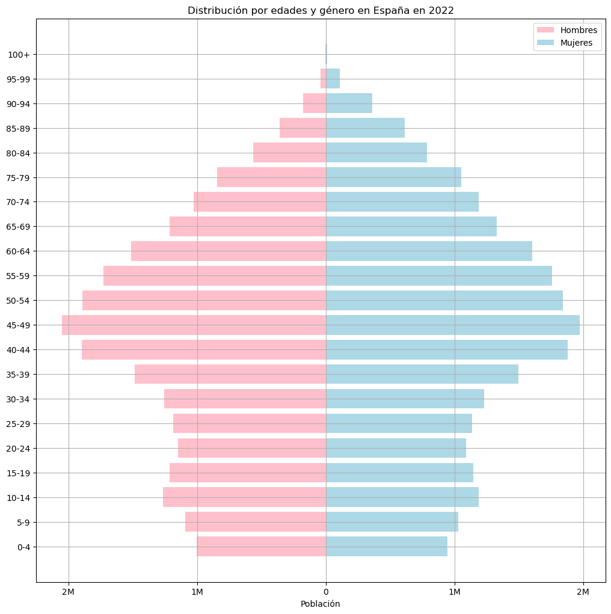

# Venn Diagrams

Fuente del conjunto de datos: [Titanic - Machine Learning from Disaster](https://www.kaggle.com/competitions/titanic) El dataset presenta el training set de la información de los pasajeros del Titanic como nombre, edad, sexo, clase socioeconómica, etc. En particular, visualizamos los conjuntos de clase de pasaje, sexo, edad categorizada y supervivencia donde el diagrama nos presenta la coincidencias entre clases en la intersección de conjuntos y, en particular, con el conjunto superviviente:

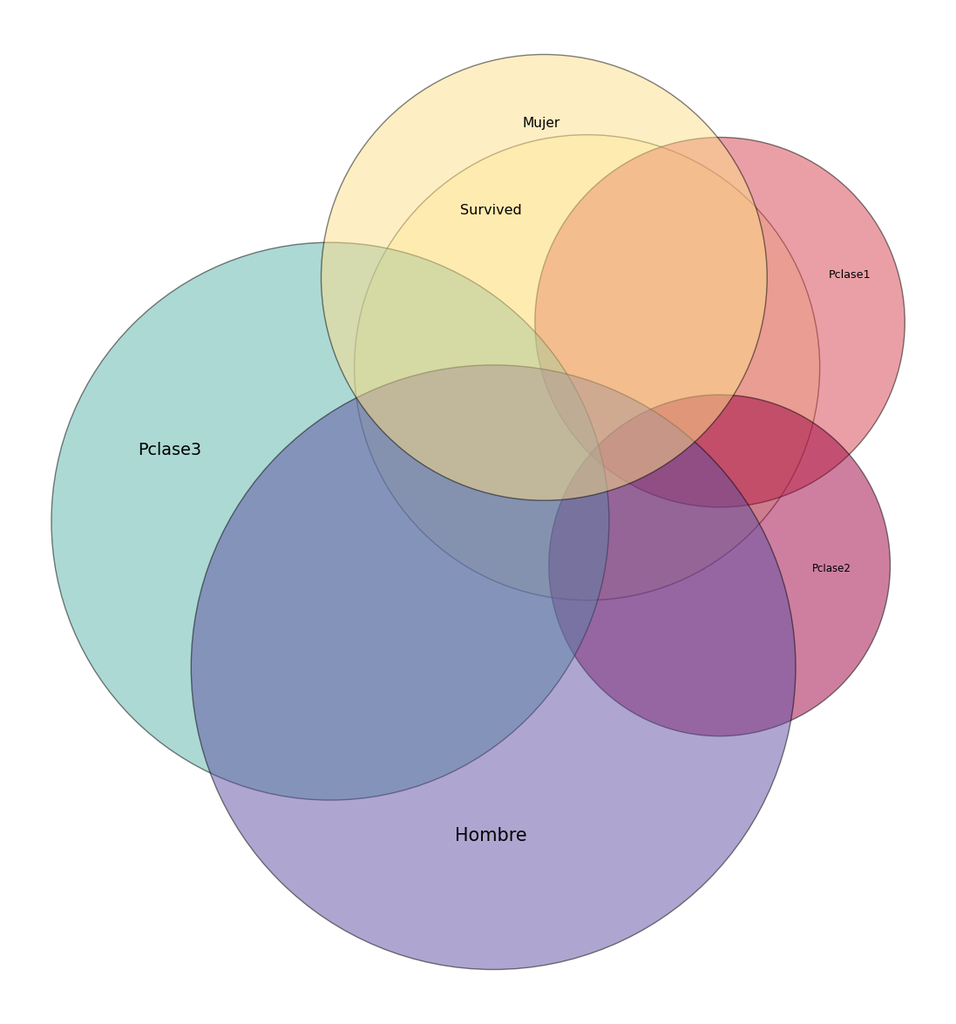

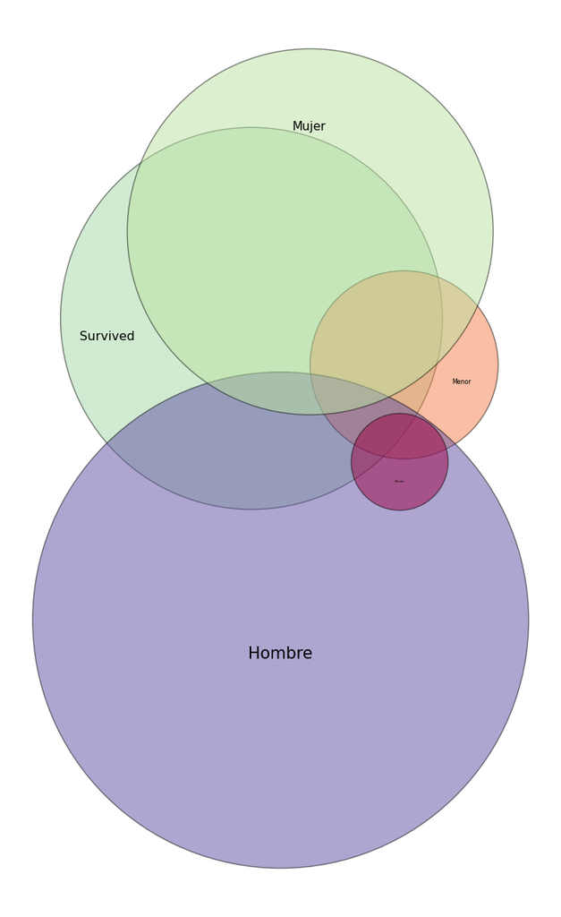

# OHLC Chart

Fuente del conjunto de datos: [400+ crypto currency pairs at 1-minute resolution](https://www.kaggle.com/datasets/tencars/392-crypto-currency-pairs-at-minute-resolution/data?select=1inchusd.csv) El dataset contiene los datos históricos de negociación (OHLC) de criptomonedas con más de 400 pares de negociación y una resolución de 1 minuto que se remontan hasta el año 2013. En particular, visualizamos las transacciones de Bitcoin US el 16 de Mayo de 2019 en una serie temporal que recoge una devaluación de carácter especulativa:

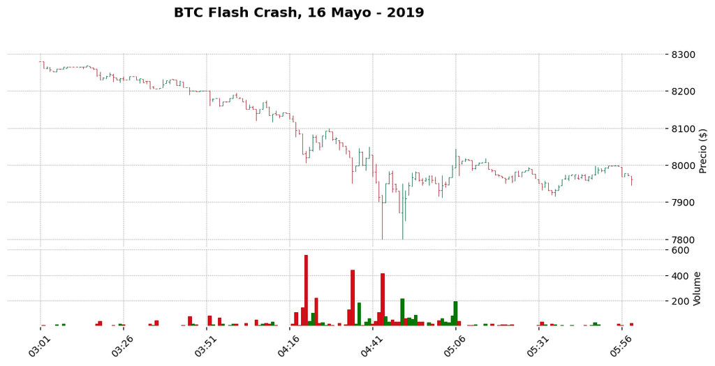